# SCLC Cell Line and Tumor Clustering

### Load R packages

```r
# BiocManager::install("biomaRt")
# library(fst)
library(rtracklayer)            # needed for readGFF if reading in fst files
library(readxl)
library(quantro)
library(biomaRt)

BiocManager::install("impute")
n

library(sva)
library(gplots)
library(quantro)
library(dendextend)
library(impute)

colbranches <- function(n, col)
{
    # code modified from https://stackoverflow.com/questions/18036094/how-to-create-a-dendrogram-with-colored-branches
    a <- attributes(n) # Find the attributes of current node
    # Color edges with requested color
    attr(n, "edgePar") <- c(a$edgePar, list(col=col, lwd=2))
    n # Don't forget to return the node!
}

# extract information from dendrogram (e.g. colors for each node)
getLeafColors <- function(mydend) {
    sd <- mydend
    myleafs <- sd %>% get_nodes_attr("label")
    myedgepar <- sd %>% get_nodes_attr("edgePar")
    mycol <- sapply(myedgepar, "[[", 1)
    names(mycol) <- myleafs
    # remove NA values (should only have sample IDs and colors left)
    mycol <- mycol[!is.na(mycol)]
    mycol <- mycol[!is.na(names(mycol))]
    return(mycol)
}
```

### Load data

First, load data, separate RNA-seq data (CCLE and Minna) and remove low-expressed genes.

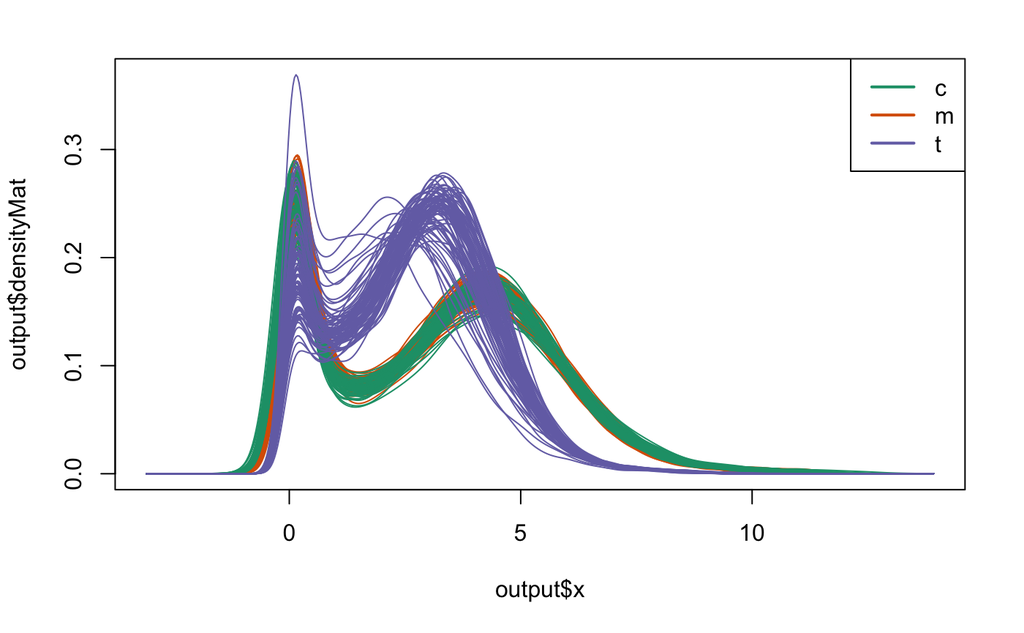

```r
cm <- read.csv("../../data/bulk-rna-seq/SCLC_combined_Minna_CCLE_batch_corrected_wo_lowgenes.csv", as.is=TRUE,
               row.names=1)

to <- read.csv(file.path('../../data/bulk-rna-seq/thomas_tumors.csv'),as.is=TRUE, row.names = 1)
t <- to
colnames(t) <- paste0('t.',colnames(t))

# different gene sets
allgenes <- sort(rownames(cm))
commongenes <- intersect(rownames(t),rownames(cm))


# combine all data keeping all genes
ad <- data.frame(gene=as.character(allgenes))
ad <- cbind(ad,cm[allgenes,])
ad <- cbind(ad,t[allgenes,])
rownames(ad) <- ad$gene
ad <- ad[,-1]
matdensity(as.matrix(ad[!apply(ad,1,function(x) any(is.na(x))),]), groupFactor=substr(colnames(ad),1,1))
legend("topright", legend=sort(unique(substr(colnames(ad),1,1))), col=RColorBrewer::brewer.pal(8, "Dark2")[1:3], lwd=2)
```

```r
# genes with missing data
genes_w_na <- rownames(ad)[apply(ad, 1, function(x) any(is.na(x)))]

# essential genes (genes that are missing from microarray data but need to be included for biological interpretation)
# missing_immune_genes <- c("NCR3LG1","MICA","ENTPD1","CD24")

lowgenes <- rownames(ad)[apply(ad, 1, function(x) all(x<log2(2)))]


# # save gene expression values of only variable genes in linear and log2 scale
# gev <- as.matrix(ad[vargenes,])
gev <- as.matrix(ad[!rownames(ad) %in% lowgenes,])

# # show which data sources have NA values for each essential gene
# message("Source with NA in specific genes")
# sapply(essential_missing_genes, function(x) sapply(c("c","m","t"), function(z)
#     anyNA(as.matrix(ad[x,substr(colnames(ad),1,1)==z]))))

# genes common to all datasets
commongenes <- rownames(ad)[!apply(ad, 1, function(x) any(is.na(x)))]
```

#### Define data to use for batch correction

Save in object `DTU` (data to use)

```r
DTU <- ad
```

#### Assume main TFs can separate subtypes

The main transcription factors (TF) that have been associated with the distinct subtypes of SCLC are:

- ASCL1
- NEUROD1
- POU2F3
- YAP1

We will assume the expression of these genes can be used to disinguish the subtypes and that the source of the data (CCLE vs Minna) is an adjustment variable.

```r
anpy <- c("ASCL1","NEUROD1","POU2F3","YAP1")
```

#### Make data.frame of temporary subtypes

Use the ANPY TF that is most highly expressed in each cell line as the subtype.

```r
# if any NEUROD1 data are NA, use NEUROD2 in place of NEUROD1 (e.g. GDSC data)
getSubtype <- function(ids,dat=DTU) {
    nd1 <- dat["NEUROD1",]
    nd2 <- sapply(seq_along(dat["NEUROD1",]), function(i)
        ifelse(is.na(dat["NEUROD1",i]), dat["NEUROD2",i],dat["NEUROD1",i]))
    if(anyNA(nd1)) dat["NEUROD1",] <- nd2
    sapply(ids, function(x) {
        out <- anpy[dat[anpy,x] == max(dat[anpy,x], na.rm=TRUE)]
        out[!is.na(out)]
    })
}

getCellLine <- function(x) gsub("^[cmS]\\.","",x)
getSource <- function(x) switch(substr(x,1,1),
                                c="CCLE",
                                m="Minna",
                                S="tumor",
                                NA)

phen <- data.frame(subtype=getSubtype(colnames(DTU)),
                   cell.line=getCellLine(colnames(DTU)),
                   source=sapply(colnames(DTU), getSource)
                   )
```

#### Before correction

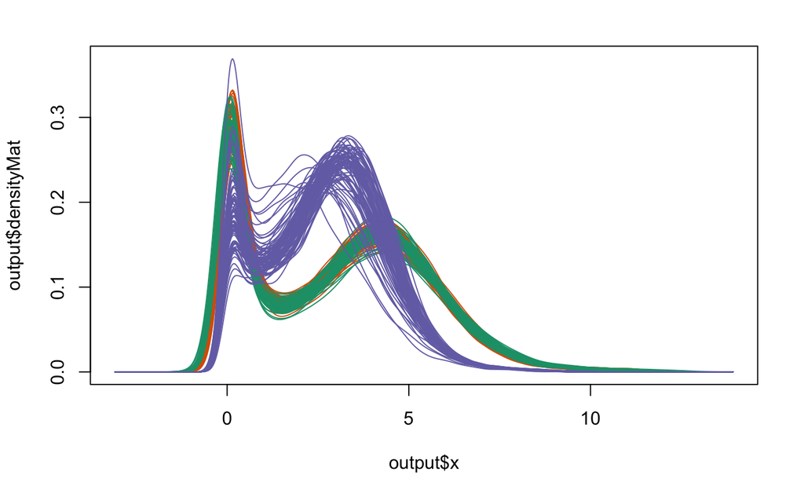

```r
matdensity(as.matrix(DTU), groupFactor=substr(colnames(DTU),1,1))
```

#### Remove batch effects using Surrogate Variable Analysis

The Bioconductor package `sva` can be used to directly remove batch effects using a Bayesian approach, `ComBat` (Johnson et al. 2007 Biostatistics). The `sva` package assumes there are two types of variables that are being considered:

1. Adjustment variables
2. Variables of interest

Two model matrices must be made: the “full model” and the “null model”. The null model is a model matrix that includes terms for all of the adjustment variables but not the variables of interest. The full model includes terms for both the adjustment variables and the variables of interest.

The model matrices can be created using the `model.matrix` function.

```r
mod <- model.matrix(~ cell.line, phen)
mod0 <- model.matrix(~ 1, phen)
```

If the `sva` function is called without the *n.sv* argument specified, the number of factors will be estimated. The number of factors can also be estimated using the `num.sv` function.

The `sva` function returns a list with four components, `sv`, `pprob.gam`, `pprob.b`, `n.sv`.

- `sv` is a matrix whose columns correspond to the estimated surrogate variables.
- `pprob.gam` is the posterior probability that each gene is associated with one or more latent variables.
- `pprob.b` is the posterior probability that each gene is associated with the variables of interest.
- `n.sv` is the number of surrogate variables estimated by the sva.

```r
library(limma)
# data for correction; must remove genes containing any NA values
# Use CCLE/Minna data
dfc <- DTU[!apply(DTU,1,function(x) any(is.na(x))),]

# Choose method for determining the number of surrogate variables
# n.sv <- num.sv(dfc, mod, method="leek")
# n.sv <- num.sv(dfc, mod, method="be")

# make a surrogate variable object
svobj <- sva(as.matrix(dfc), mod, mod0)

# plot it
plot(svobj$sv, pch=19)

modSv = cbind(mod,svobj$sv)
mod0Sv = cbind(mod0,svobj$sv)
fit = lmFit(dfc,modSv)

# make a frozen surrogate variable object (i.e. batch-corrected)
fsvobj <- fsva(as.matrix(dfc), mod, svobj, newdat=as.matrix(dfc))
#

# batch-corrected data
bc <- fsvobj$new
plot(fsvobj$newsv, pch=19)

bc2 <- ComBat(as.matrix(dfc), batch=substr(colnames(dfc),1,1), mod = mod0,ref.batch = 'm')

bc2_mean.only <- ComBat(as.matrix(dfc), batch=substr(colnames(dfc),1,1), mod = mod0,mean.only = TRUE)
# write.csv(bc2, file="../data/CCLE_Minna_Thomas_COMBAT.csv")
```

[output not shown]

#### After correction

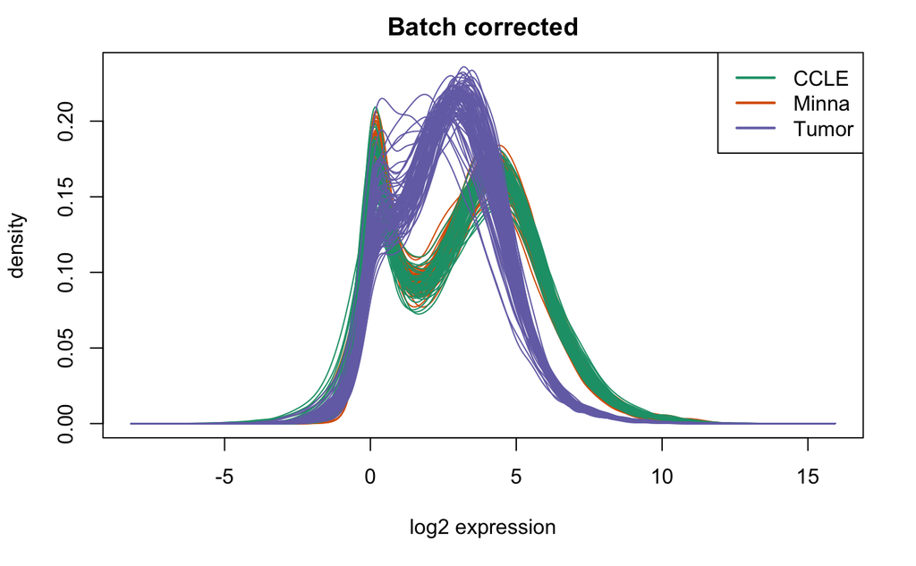

```r
matdensity(bc, main="Batch corrected", xlab="log2 expression", ylab="density",
           groupFactor=substr(colnames(bc2),1,1))
legend("topright",legend=c("CCLE","Minna","Tumor"), col=RColorBrewer::brewer.pal(8, "Dark2")[1:3], lwd=2)
```

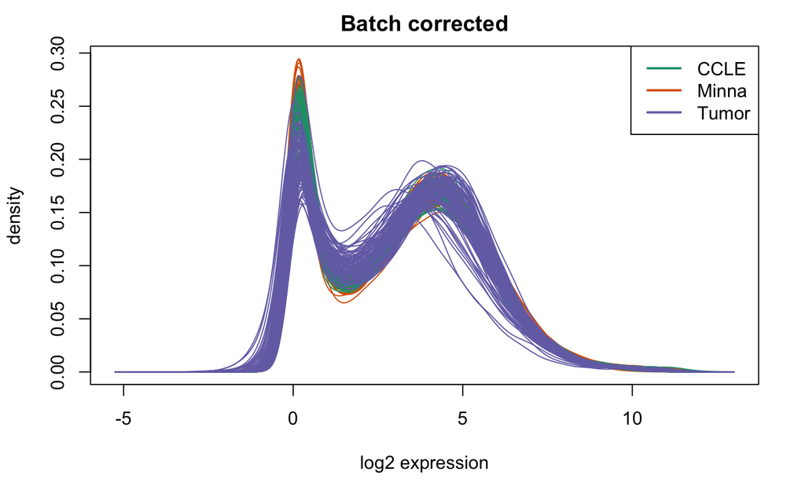

```r
matdensity(bc2, main="Batch corrected", xlab="log2 expression", ylab="density",
           groupFactor=substr(colnames(bc2),1,1))
legend("topright",legend=c("CCLE","Minna","Tumor"), col=RColorBrewer::brewer.pal(8, "Dark2")[1:3], lwd=2)
```

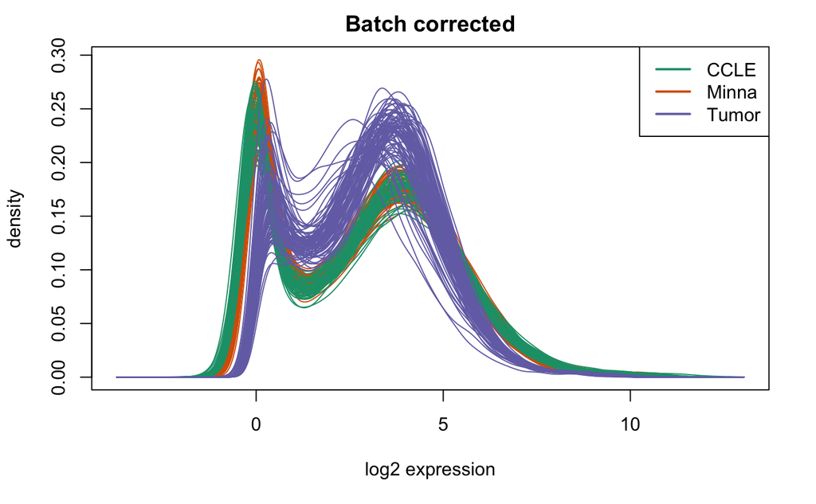

```r
matdensity(bc2_mean.only, main="Batch corrected", xlab="log2 expression", ylab="density",
           groupFactor=substr(colnames(bc2),1,1))
legend("topright",legend=c("CCLE","Minna","Tumor"), col=RColorBrewer::brewer.pal(8, "Dark2")[1:3], lwd=2)
```

# Clustering C and M datasets

#### Heatmap using 1-Spearman coeff as distance

```r
# pdf(file="../figures/hm_temp_vargenes.pdf", height=8, width=8)
data <- '../data/SCLC_combined_Minna_CCLE_batch_corrected_wo_lowgenes.csv'
x <- read.csv(data, header = TRUE, sep = ',', row.names = 1)
x <- as.matrix(x)
hm <- heatmap(x,
        keep.dendro = TRUE,
        col=bluered(20),
        distfun = function(x) as.dist(1-cor(t(x), method='spearman')),
        cexRow=0.25, cexCol=0.25
        )
# dev.off()
```

[output not shown]

#### Extract dendrogram from heatmap

```r
#pdf(file="./figures/no_lowgenes_hc_spearman.pdf", height=8, width=8)
hm.dend <-  as.dendrogram(hm[['Colv']])
nodePar <- list(lab.cex = 0.25, pch = c(NA, 19),
                cex = 0.25, col = "blue")
# pdf(file="../figures/supplement/hc_cline_tumors_all_genes.pdf", height=8, width=8)

#plot(hm.dend,  nodePar = nodePar, horiz = TRUE, xlim=c(0.7,0))
sd <- hm.dend
#dev.off()
```

```r
data_labels <-'/Users/smgroves/Documents/MATLAB/particode/Data/combined_clusters_2020-05-27-MC copy.csv'

# data_labels <-'../data/combined_clusters.csv'
labels <- read.csv(data_labels, header = TRUE, sep = ',', row.names = 1)
labels <- labels[row.names(xt),]
colors_to_use <- as.numeric(xt$ASCL1)
colors_to_use <- colors_to_use[order.dendrogram(hm.dend)]
pdf(file="./figures/dend_ASCL1.pdf", height=20, width=40)

barplot(colors_to_use, names.arg = rownames(labels)[order.dendrogram(hm.dend)],las = 2)
dev.off()
labels_colors(hm.dend) <- colors_to_use
pdf(file="./figures/no_lowgenes_hc_NEUROD1.pdf", height=20, width=20)
nodePar <- list(lab.cex = 0.25, pch = c(NA, 19),
                cex = 0.25, col = "blue")
plot(hm.dend,  nodePar = nodePar, horiz = TRUE, xlim=c(0.5,0))
dev.off()
```

#### Compare to prior clustering

```r
subt_v2 <- read.csv('../data/combined_clusters_2020-04-28.csv',as.is=TRUE, row.names=1)
# subt_v3 <- read.csv('../data/combined_clusters_2020-05-27.csv',as.is=TRUE, row.names=1)
mysubt$subtype_v2 <- subt_v2[rownames(mysubt),"subtype"]
mysubt$subtype_v3 <- subt_v3[rownames(mysubt),"subtype"]
```

#### Test PlotByPhen on new clustering

*Note that the statistical tests are biased in these graphs due to overrepresentation of cell lines with samples in more than one datset. Those data should be averaged across the datasets to obtain a single value for each cell line.*

First load function and necessary data (need an object names `clusters` with phenotype data in it).

```r
source('/Users/smgroves/Documents/Github/SCLC/RNA-seq/code/ShinyApps/plotByPhenShiny/PlotByPhen.r', chdir = TRUE)
clusters <- mysubt
clusters$nphenotype <- clusters$phenotype <- mysubt$subtype
```

Examine expression patterns of TFs.

```r
TF_genes_to_test <- c("ASCL1","NEUROD1","YAP1","POU2F3","ELF3","ISL1","INSM1","MYC","MYCL","DLX5",
                      "NOTCH1","NOTCH2","HES1","REST","NR0B2","SMAD3","NKX2-1","NEUROD2")

invisible(sapply(TF_genes_to_test, function(x) plotByPhen(x, dat=bc)))
```

[output not shown]

Examine expression patterns of other genes (e.g. NE markers and genes thought to be involved in lung development).

```r
other_genes_to_test <- c("CALCA","SEC11C","DLL3","NCAM1","FGFR1","RET","BCL2","GRP","SCNN1A","CEACAM5")

invisible(sapply(other_genes_to_test, function(x) plotByPhen(x, dat=bc)))
```

[output not shown]

#### Save normalized data to file

```r
write.csv(bc, file="../data/SCLC_CCLE_Minna_Thomas_allgenes.csv")
write.csv(clusters, file="../data/combined_clusters.csv")
write.csv(data.frame(vargenes=vargenes), file="../data/variable_genes.csv", row.names=FALSE)
```

### Batch correct only RNA-seq data

Since microarray data are missing many genes, some analyses should be performed using only RNA-seq data. These data still require batch correction.

```r
# data for correction; must remove genes containing any NA values
# Use CCLE/Minna data
dfc_cm <- cm[!apply(cm,1,function(x) any(is.na(x))),]
phen_cm <- data.frame(subtype=getSubtype(colnames(dfc_cm), dat=dfc_cm),
                   cell.line=getCellLine(colnames(dfc_cm)),
                   source=sapply(colnames(dfc_cm), getSource)
                   )
mod_cm <- model.matrix(~ cell.line, phen_cm)
bc_cm <- ComBat(as.matrix(dfc_cm), batch=substr(colnames(dfc_cm),1,1), mod=mod_cm)
```

#### After correction

```r
matdensity(bc_cm, main="Batch corrected", xlab="log2 expression", ylab="density",
           groupFactor=substr(colnames(bc_cm),1,1))
legend("topright",legend=c("CCLE","Minna"), col=RColorBrewer::brewer.pal(8, "Dark2")[1:2], lwd=2)
```

[output not shown]

#### Identify genes that are highly expressed and not different across subtypes

```r
lmp <- function (modelobject) {
    if (class(modelobject) != "lm") stop("Not an object of class 'lm' ")
    f <- summary(modelobject)$fstatistic
    p <- pf(f[1],f[2],f[3],lower.tail=F)
    attributes(p) <- NULL
    return(p)
}

ctrl_genes <- character()
he <- bc_cm[apply(bc_cm,1, function(x) all(x>5)),]
he <- he[,rownames(clusters)[!grepl("^g",rownames(clusters))]]
subt <- clusters[!grepl("^g",rownames(clusters)),"subtype"]
the <- cbind(data.frame(subtype=subt),t(he))
heg <- colnames(the)[-1]
m <- sapply(heg, function(gene) {
    mymod <- formula(paste(gene,"~ subtype"))
    lmp(lm(mymod, dat=the))
})

ctrl_genes <- names(sort(m[m>0.2],decreasing=TRUE))
```

#### Write control genes to file

```r
write.csv(data.frame(control_gene=ctrl_genes), file="../data/control_genes.csv", row.names=FALSE)
```